# COVID-19 and Vaccine Confidence Data: EDA Executive Summary

Jamie Lee

11/25/2020

### Table of Contents

**Introduction**  
**New COVID-19 Cases Per Million Over Time and Stringency Index**  
**Different Religions and Vaccine Compatibility with Religious Beliefs**  
**Conclusion**  
**Citations**

### Introduction

Although a lot of exploration was done with various accompanying visualizations for the COVID-19 data and vaccine confidence data, there were some that particularly stood out as most interesting. The first is a plot showing the progression of new COVID-19 cases per million and stringency index in the USA over time. The second is a plot showing the percentages of reported vaccine compatibility with religious beliefs across different religions.

```r
library(tidyverse)
library(janitor)
library(ggplot2)
library(lubridate)
```

```r
left_joined_data <- read_rds("data/data processed/Joined Data.rds")
vaccine_conf_1_data_new <- read_rds("data/data processed/Vaccine Confidence 1 Data.rds")
vaccine_conf_other <- read_rds("data/data processed/Vaccine Confidence Other Data.rds")
covid_data <- read_rds("data/data processed/Covid-19 Data.rds")
```

### New COVID-19 Cases Per Million Over Time and Stringency Index

I created a plot that shows the number of new COVID-19 cases per million for the United States over time with each point representing a day. The points’ color represents the stringency index - a numerical measure of how strict a country’s government was with COVID-19 precautionary measures, with a higher stringency index meaning greater strictness. Given how relevant this pandemic is to everyone in the US (and the rest of the world), I thought this would be especially interesting to share. There are two clear peaks - the first around April and the second around August. Stringency index was highest with the first wave, and got a bit lower with the second wave.

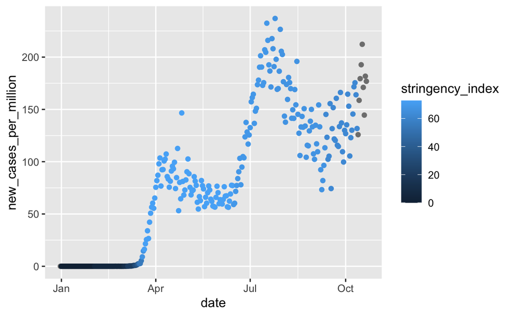

```r
left_joined_data %>%
  filter(location == "United States") %>%
  mutate(date = mdy(date)) %>%
  ggplot() +
  geom_point(aes(x = date, y = new_cases_per_million, color = stringency_index))
```

### Different Religions and Vaccine Compatibility with Religious Beliefs

Below is a plot of the levels of vaccine compatibility with religious beliefs across different religions. This was fascinating because I expected Christianity to have the lowest compatibility given what I have seen in the news with certain Christian denominations opposing vaccines. However I was surprised to find that, at least from this sample of people, Buddhism is lowest in the percentage of those who strongly agree and highest in the percentage of people who tend to disagree.

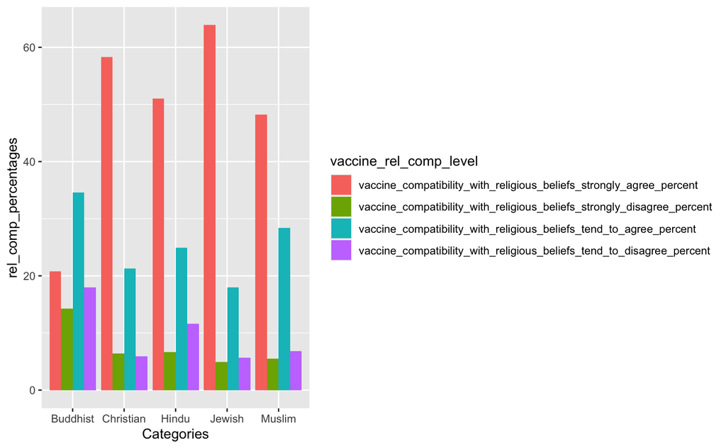

```r
colnames(vaccine_conf_other)[1] <- "Categories"

levels_to_exclude_rel_beliefs <- c("vaccine_compatibility_with_religious_beliefs_agree_percent",
                            "vaccine_compatibility_with_religious_beliefs_disagree_percent",
                            "vaccine_compatibility_with_religious_beliefs_do_not_know_no_response_percent")

vaccine_conf_other %>%
  filter(Categories %in% c("Christian", "Muslim", "Hindu", "Buddhist", "Jewish",
          "Athiest")) %>%
  pivot_longer(cols = (starts_with("vaccine_compatibility_with_religious_beliefs")
              & ends_with("percent")), names_to = "vaccine_rel_comp_level",
               values_to = "rel_comp_percentages") %>%
  filter(!vaccine_rel_comp_level %in% levels_to_exclude_rel_beliefs) %>%
  ggplot() +
  geom_bar(aes(x = Categories, y= rel_comp_percentages, fill = vaccine_rel_comp_level),
           position = "dodge", stat = "identity")
```

### Conclusion

COVID-19 and vaccine confidence are both topics we hear about in the media often, and although just two plots, these visualizations capture a lot of information in one place which allows for easier comparison and lead to interesting insights.

### Citations

Mathieu, et.al, 2020. “covid-19 data”, https://github.com/owid/covid-19-data, Our World in Data.  
S., Claudia. 2020. “Vaccine Confidence Data - v2 via Gapminder”, https://docs.google.com/spreadsheets/d/1_EN4eAOS7zugaxQeEVYYVwFy3iFcBqzp5J6vvEGxJfI/edit#gid=501532268, World Bank, V2.